# survival

## Introduction

This vignette provides an example workflow for analyzing myeloma data using R packages. The goal is to demonstrate various steps involved in the analysis, including data preprocessing, survival analysis, and predictive modeling using ODA and CTA.

## Data Preparation

Ensure that `project_dir` points to a valid directory path on your system, and uncomment the `setwd()` line to set the working directory accordingly.

Remember to replace `"~/Workshop"` with the appropriate directory path for your case.

```r
# Replace "~" with your own directory path
project_dir <- "~/Workshop"

# Set the working directory to "project_dir"

# Myeloma data extracted from publicly available gene expression data (GEO Id: GSE4581)
data("myeloma")

glimpse(myeloma)
```

```
#> Rows: 256
#> Columns: 11
#> $ molecular_group <fct> Cyclin D-1, Cyclin D-2, MMSET, MMSET, MAF, Hyperdiploi~
#> $ chr1q21_status  <fct> 3 copies, 2 copies, 2 copies, 3 copies, NA, 2 copies, ~
#> $ treatment       <fct> TT2, TT2, TT2, TT2, TT2, TT2, TT2, TT2, TT2, TT2, TT2,~
#> $ event           <int> 0, 0, 0, 1, 0, 0, 1, 0, 1, 1, 1, 1, 0, 1, 1, 1, 0, 1, ~
#> $ time            <dbl> 69.24, 66.43, 66.50, 42.67, 65.00, 65.20, 38.27, 64.33~
#> $ CCND1           <dbl> 9908.4, 16698.8, 294.5, 241.9, 472.6, 664.1, 1011.1, 1~
#> $ CRIM1           <dbl> 420.9, 52.0, 617.9, 11.9, 38.8, 16.9, 151.9, 81.7, 9.1~
#> $ DEPDC1          <dbl> 523.5, 21.1, 192.9, 184.7, 212.0, 341.6, 154.1, 195.5,~
#> $ IRF4            <dbl> 16156.5, 16946.2, 8903.9, 11894.7, 7563.1, 16023.4, 16~
#> $ TP53            <dbl> 10.0, 1056.9, 1762.8, 946.8, 361.4, 2096.3, 2580.0, 23~
#> $ WHSC1           <dbl> 261.9, 363.8, 10042.9, 4931.0, 165.0, 569.2, 165.1, 36~
```

```r
myeloma %>%
  filter(time==0) # exclude time=0 (v2=0) event from survival analysis
```

```
#>          molecular_group chr1q21_status treatment event time CCND1 CRIM1 DEPDC1
#> GSM51054      Cyclin D-2           <NA>       TT2     1    0 155.1 494.3  401.1
#>             IRF4  TP53 WHSC1
#> GSM51054 14353.1 593.5 230.6
```

```r
# Create dummy coded variables for char and factor variables
myeloma.oda <- dummy_cols(myeloma, select_columns = c("molecular_group", "chr1q21_status"))

glimpse(myeloma.oda)
```

```
#> Rows: 256
#> Columns: 22
#> $ molecular_group                    <fct> Cyclin D-1, Cyclin D-2, MMSET, MMSE~
#> $ chr1q21_status                     <fct> 3 copies, 2 copies, 2 copies, 3 cop~
#> $ treatment                          <fct> TT2, TT2, TT2, TT2, TT2, TT2, TT2, ~
#> $ event                              <int> 0, 0, 0, 1, 0, 0, 1, 0, 1, 1, 1, 1,~
#> $ time                               <dbl> 69.24, 66.43, 66.50, 42.67, 65.00, ~
#> $ CCND1                              <dbl> 9908.4, 16698.8, 294.5, 241.9, 472.~
#> $ CRIM1                              <dbl> 420.9, 52.0, 617.9, 11.9, 38.8, 16.~
#> $ DEPDC1                             <dbl> 523.5, 21.1, 192.9, 184.7, 212.0, 3~
#> $ IRF4                               <dbl> 16156.5, 16946.2, 8903.9, 11894.7, ~
#> $ TP53                               <dbl> 10.0, 1056.9, 1762.8, 946.8, 361.4,~
#> $ WHSC1                              <dbl> 261.9, 363.8, 10042.9, 4931.0, 165.~
#> $ `molecular_group_Cyclin D-1`       <int> 1, 0, 0, 0, 0, 0, 0, 0, 0, 0, 0, 0,~
#> $ `molecular_group_Cyclin D-2`       <int> 0, 1, 0, 0, 0, 0, 0, 0, 0, 0, 0, 0,~
#> $ molecular_group_Hyperdiploid       <int> 0, 0, 0, 0, 0, 1, 1, 1, 0, 1, 0, 0,~
#> $ `molecular_group_Low bone disease` <int> 0, 0, 0, 0, 0, 0, 0, 0, 0, 0, 0, 0,~
#> $ molecular_group_MAF                <int> 0, 0, 0, 0, 1, 0, 0, 0, 0, 0, 0, 0,~
#> $ molecular_group_MMSET              <int> 0, 0, 1, 1, 0, 0, 0, 0, 0, 0, 1, 0,~
#> $ molecular_group_Proliferation      <int> 0, 0, 0, 0, 0, 0, 0, 0, 1, 0, 0, 1,~
#> $ `chr1q21_status_2 copies`          <int> 0, 1, 1, 0, NA, 1, 1, 1, 0, 0, 0, 0~
#> $ `chr1q21_status_3 copies`          <int> 1, 0, 0, 1, NA, 0, 0, 0, 1, 1, 0, 0~
#> $ `chr1q21_status_4+ copies`         <int> 0, 0, 0, 0, NA, 0, 0, 0, 0, 0, 1, 1~
#> $ chr1q21_status_NA                  <int> 0, 0, 0, 0, 1, 0, 0, 0, 0, 0, 0, 0,~
```

```r
# remove non-compatable char and factor variables from analysis
myeloma.oda <- myeloma.oda[-c(1:3)]

# create ODA project in current directory
#ODAtree("myeloma") # already run

# Set the working directory to "myeloma"
```

## ODA Run 1. Time-weighted models

Here we will evaluate all attributes in a time-weighted uniODA analysis. LOO stable predictors are sought for use in building CTA models. We will need to `setwd("myeloma")` before executing.

```r
# write the data file to the project directory
#write.csv(file = "/ODA/data.csv", myeloma.oda, row.names = FALSE)

# running this pre-processing code will create a cleaned (NA removed, replaced with -9) data.txt file
#ODAclean(data="data.csv",output = 1, type="ODA") # already run

#review the variable names and aliases to be used in command syntax
ODAload(1,type = "oda")

oda.key.1
```

```
#>                               label variable
#> 1                             event       v1
#> 2                              time       v2
#> 3                             CCND1       v3
#> 4                             CRIM1       v4
#> 5                            DEPDC1       v5
#> 6                              IRF4       v6
#> 7                              TP53       v7
#> 8                             WHSC1       v8
#> 9        molecular_group_Cyclin.D.1       v9
#> 10       molecular_group_Cyclin.D.2      v10
#> 11     molecular_group_Hyperdiploid      v11
#> 12 molecular_group_Low.bone.disease      v12
#> 13              molecular_group_MAF      v13
#> 14            molecular_group_MMSET      v14
#> 15    molecular_group_Proliferation      v15
#> 16          chr1q21_status_2.copies      v16
#> 17          chr1q21_status_3.copies      v17
#> 18         chr1q21_status_4..copies      v18
#> 19                chr1q21_status_NA      v19
```

```r
# Create ODA command syntax file within the run directory, then execute the batch file
# ODArun(run=1, # this will take about 15 minutes to run to completion
#        vstart="v1",
#        vend="v19",
#        class="v1",
#        attribute="v3 to v8 v9 v11 v12 v14 v15 v16 v17 v18 v19", # exclude v10 and v13, no solutions found
#        miss="-9",
#        exclude = "v2=0",
#        weight="v2") # time weighted ODA model

# once batch completes, the resulting model file will be moved to outputs folder

# the resulting model can then be parsed and reviewed
ODAparse(run=1,mod=1)

oda.model.1.1
```

```
#>    Model:                IF Attributes:  THEN Predict: Overall ESS:
#> 1       1       V3 <= 57.0 , 57.0 < V3  V1 = 1, V1 = 0        2.36%
#> 2       2   V4 <= 890.25 , 890.25 < V4  V1 = 0, V1 = 1        6.22%
#> 3       3     V5 <= 528.1 , 528.1 < V5  V1 = 0, V1 = 1       14.42%
#> 4       4 V6 <= 20604.0 , 20604.0 < V6  V1 = 0, V1 = 1        2.41%
#> 5       5     V7 <= 432.1 , 432.1 < V7  V1 = 1, V1 = 0        7.62%
#> 6       6   V8 <= 3212.7 , 3212.7 < V8  V1 = 0, V1 = 1       18.61%
#> 7       7         V9 <= 0.5 , 0.5 < V9  V1 = 0, V1 = 1       -1.89%
#> 8       8       V11 <= 0.5 , 0.5 < V11  V1 = 0, V1 = 1       -5.68%
#> 9       9       V12 <= 0.5 , 0.5 < V12  V1 = 0, V1 = 1       -6.73%
#> 10     10       V14 <= 0.5 , 0.5 < V14  V1 = 0, V1 = 1       12.11%
#> 11     11       V15 <= 0.5 , 0.5 < V15  V1 = 0, V1 = 1       14.21%
#> 12     12       V16 <= 0.5 , 0.5 < V16  V1 = 1, V1 = 0       17.56%
#> 13     13       V17 <= 0.5 , 0.5 < V17  V1 = 0, V1 = 1       15.99%
#> 14     14       V18 <= 0.5 , 0.5 < V18  V1 = 0, V1 = 1        1.57%
```

[output cut: 33 more lines]

```r
oda.list.1.1[10] # there is one v2=0 event at time zero, must subtract from table
```

```
#> $pv.10
#> $pv.10$v1
#>    x
#> v1    0   1
#>   0 160  26
#>   1  51  18
```

```r
sn <-18/(18+51)
sp <-160/(160+26)

100*(((sn+sp)/2) - 0.5) / 0.5
```

```
#> [1] 12.10846
```

```r
oda.model.1.1[10,]
```

```
#>    Model:          IF Attributes:  THEN Predict: Overall ESS: Overall ESP:
#> 10     10 V14 <= 0.5 , 0.5 < V14  V1 = 0, V1 = 1       12.11%       16.74%
#>    Weighted ESS: Weighted ESP: MC P-value:  LOO ESS: LOO ESP: Weighted LOO ESS:
#> 10        14.06%        14.56%    0.015400    12.11%   16.74%            14.06%
#>    Weighted LOO ESP: LOO P-value:
#> 10            14.56%      .020704
```

```r
ODAsummary(1.1)

oda.summary.1.1 %>%
  filter(Weighted.LOO.ESS.==Weighted.ESS.) %>%
  select(Model.,IF.Attributes.,THEN.Predict.,LOO.P.value. ) # v4 v9 v11 v12 v14 to v19
```

```
#>    Model.                     IF.Attributes.         THEN.Predict. LOO.P.value.
#> 1       2 c("V4 <= 890.25 ", "890.25 < V4 ") c("V1 = 0", "V1 = 1")      .077922
#> 2       7       c("V9 <= 0.5 ", "0.5 < V9 ") c("V1 = 0", "V1 = 1")      .761854
#> 3       8     c("V11 <= 0.5 ", "0.5 < V11 ") c("V1 = 0", "V1 = 1")      .860673
#> 4       9     c("V12 <= 0.5 ", "0.5 < V12 ") c("V1 = 0", "V1 = 1")      .959082
#> 5      10     c("V14 <= 0.5 ", "0.5 < V14 ") c("V1 = 0", "V1 = 1")      .020704
#> 6      11     c("V15 <= 0.5 ", "0.5 < V15 ") c("V1 = 0", "V1 = 1")      .002371
#> 7      12     c("V16 <= 0.5 ", "0.5 < V16 ") c("V1 = 1", "V1 = 0")      .023989
#> 8      13     c("V17 <= 0.5 ", "0.5 < V17 ") c("V1 = 0", "V1 = 1")      .026899
#> 9      14     c("V18 <= 0.5 ", "0.5 < V18 ") c("V1 = 0", "V1 = 1")      .479566
#> 10     15     c("V19 <= 0.5 ", "0.5 < V19 ") c("V1 = 0", "V1 = 1")      .641066
```

## CTA Run 1. MDSA step 1

We will construct time-weighted CTA models using the LOO-stable ODA attributes from ODA Run 1. Here we will start by setting mindenom to 1, which is an unrestricted minimum denominator.

```r
#write.csv(file="CTA/data.csv",myeloma.oda,row.names = F)

#ODAclean(data="data.csv",output = 1, type="CTA")

ODAload(1,type = "cta")

#review the variable labels and aliases
cta.key.1
```

```
#>                               label variable
#> 1                             event       v1
#> 2                              time       v2
#> 3                             CCND1       v3
#> 4                             CRIM1       v4
#> 5                            DEPDC1       v5
#> 6                              IRF4       v6
#> 7                              TP53       v7
#> 8                             WHSC1       v8
#> 9        molecular_group_Cyclin.D.1       v9
#> 10       molecular_group_Cyclin.D.2      v10
#> 11     molecular_group_Hyperdiploid      v11
#> 12 molecular_group_Low.bone.disease      v12
#> 13              molecular_group_MAF      v13
#> 14            molecular_group_MMSET      v14
#> 15    molecular_group_Proliferation      v15
#> 16          chr1q21_status_2.copies      v16
#> 17          chr1q21_status_3.copies      v17
#> 18         chr1q21_status_4..copies      v18
#> 19                chr1q21_status_NA      v19
```

```r
# Create CTA command syntax file within the run directory, then execute the batch file
# CTArun(run=1,
#        vstart="v1",
#        vend="v19",
#        class="v1",
#        attribute="v4 v9 v11 v12 v14 to v19", # wess stable in training and loo
#        miss="-9",
#        exclude = "v2=0",
#        weight="v2",
#        mindenom = 1,
#        enumerate = T)

# once batch completes, the resulting model file will be moved to outputs folder

# the resulting model can then be parsed and reviewed
# note syntax below differs from ODAparse() as it includes type and weight
CTAparse(run=1,mod=1,type="Enumerated",weight=T)
```

```
#> The smallest observed wD statistic was: 7.834236
#> Model(s) with the smallest observed wD statistic: 3
#> The minimum observed denominator value was: 29
#> Model(s) with the minimum observed denominator value: 3
```

```r
cta.sum.1.1
```

```
#>   tree.num     Result Class mindenom n.class.0 n.class.1 Sensitivity Specificiy
#> 1        3 Enumerated    V1       29       186        69       47.83      78.49
#>     PPV   NPV Mean.PAC   ESS Strata   D Weighted.ESS       wD
#> 1 45.21 80.22    63.16 26.32      3 8.4        27.69 7.834236
```

## CTA Run 2. MDSA step 2

Here we are updating the syntax for Run 2 by increasing the entered mindenom by adding 1 to the smallest denominator from Run 1.

```r
#write.csv(file="CTA/data.csv",myeloma.oda,row.names = F)

#ODAclean(data="data.csv",output = 2, type="CTA")

ODAload(2,type = "cta")

#review the variable labels and aliases
cta.key.2
```

```
#>                               label variable
#> 1                             event       v1
#> 2                              time       v2
#> 3                             CCND1       v3
#> 4                             CRIM1       v4
#> 5                            DEPDC1       v5
#> 6                              IRF4       v6
#> 7                              TP53       v7
#> 8                             WHSC1       v8
#> 9        molecular_group_Cyclin.D.1       v9
#> 10       molecular_group_Cyclin.D.2      v10
#> 11     molecular_group_Hyperdiploid      v11
#> 12 molecular_group_Low.bone.disease      v12
#> 13              molecular_group_MAF      v13
#> 14            molecular_group_MMSET      v14
#> 15    molecular_group_Proliferation      v15
#> 16          chr1q21_status_2.copies      v16
#> 17          chr1q21_status_3.copies      v17
#> 18         chr1q21_status_4..copies      v18
#> 19                chr1q21_status_NA      v19
```

```r
# CTArun(run=2,
#        vstart="v1",
#        vend="v19",
#        class="v1",
#        attribute="v4 v9 v11 v12 v14 to v19", # wess stable in training and loo
#        miss="-9",
#        exclude = "v2=0",
#        weight="v2",
#        mindenom = 30, #  mindenom from Run 1 was 29, so Run 2 mindenom = 30
#        enumerate = T)

CTAparse(run=2,mod=1,type="Enumerated",weight=T)
```

```
#> The smallest observed wD statistic was: 10.11387
#> Model(s) with the smallest observed wD statistic: 3
#> The minimum observed denominator value was: 55
#> Model(s) with the minimum observed denominator value: 3
```

```r
cta.sum.2.1
```

```
#>   tree.num     Result Class mindenom n.class.0 n.class.1 Sensitivity Specificiy
#> 1        3 Enumerated    V1       55       135        51       41.18      74.81
#>     PPV  NPV Mean.PAC   ESS Strata     D Weighted.ESS       wD
#> 1 38.18 77.1       58 15.99      2 10.51        16.51 10.11387
```

## CTA Run 3. MDSA step 3

Here we are updating the syntax for Run 3 by increasing the entered mindenom by adding 1 to the smallest denominator from Run 2.

```r
#write.csv(file="CTA/data.csv",myeloma.oda,row.names = F)

#ODAclean(data="data.csv",output = 3, type="CTA")

ODAload(3,type = "cta")

#review the variable labels and aliases
cta.key.3
```

```
#>                               label variable
#> 1                             event       v1
#> 2                              time       v2
#> 3                             CCND1       v3
#> 4                             CRIM1       v4
#> 5                            DEPDC1       v5
#> 6                              IRF4       v6
#> 7                              TP53       v7
#> 8                             WHSC1       v8
#> 9        molecular_group_Cyclin.D.1       v9
#> 10       molecular_group_Cyclin.D.2      v10
#> 11     molecular_group_Hyperdiploid      v11
#> 12 molecular_group_Low.bone.disease      v12
#> 13              molecular_group_MAF      v13
#> 14            molecular_group_MMSET      v14
#> 15    molecular_group_Proliferation      v15
#> 16          chr1q21_status_2.copies      v16
#> 17          chr1q21_status_3.copies      v17
#> 18         chr1q21_status_4..copies      v18
#> 19                chr1q21_status_NA      v19
```

```r
# CTArun(run=3,
#        vstart="v1",
#        vend="v19",
#        class="v1",
#        attribute="v4 v9 v11 v12 v14 to v19", # wess stable in training and loo
#        miss="-9",
#        exclude = "v2=0",
#        weight="v2",
#        mindenom = 56, #  mindenom from Run 2 was 55, so Run 3 mindenom = 56
#        enumerate = T)

#CTAparse(run=3,mod=1,type="Enumerated",weight=T) # Error: no tree found
```

## Select Globally Optimal (GO) Model

Review the results from CTA models in Run 1 and Run 2.

These are the descendant family of models. Run 1 has a lowest wD value.

CTA Run 1 Model 1 is therefore the globally optimal (GO) model for this outcome.

```r
cta.sum.1.1
```

```
#>   tree.num     Result Class mindenom n.class.0 n.class.1 Sensitivity Specificiy
#> 1        3 Enumerated    V1       29       186        69       47.83      78.49
#>     PPV   NPV Mean.PAC   ESS Strata   D Weighted.ESS       wD
#> 1 45.21 80.22    63.16 26.32      3 8.4        27.69 7.834236
```

```r
cta.model.1.1
```

```
#> $model.3
#>   ATTRIBUTE NODE LEVEL OBS    P   WESS    LOO  WESSL LOOp TYPE    IF THEN
#> 1       V14    1     1 255 .015 14.06% STABLE 14.06% .015  ORD <=0.5    0
#> 2       V15    2     2 211 .001 20.71% STABLE 20.71% .001  ORD <=0.5    0
#>        N1 PERCENT1   IF THEN    N2 PERCENT2
#> 1 160/211   75.83% >0.5    1 18/44  40.91%*
#> 2 146/182  80.22%* >0.5    1 15/29  51.72%*
```

```r
cta.list.1.1
```

```
#> $model.3
#>   Class Pred 0 Pred 1   Sens Weighted Sens     PV Weighted PV
#> 1     0    146     40 78.49%        78.28% 80.22%      88.07%
#> 2     1     36     33 47.83%        49.40% 45.21%      32.29%
```

```r
cta.key.1
```

```
#>                               label variable
#> 1                             event       v1
#> 2                              time       v2
#> 3                             CCND1       v3
#> 4                             CRIM1       v4
#> 5                            DEPDC1       v5
#> 6                              IRF4       v6
#> 7                              TP53       v7
#> 8                             WHSC1       v8
#> 9        molecular_group_Cyclin.D.1       v9
#> 10       molecular_group_Cyclin.D.2      v10
#> 11     molecular_group_Hyperdiploid      v11
#> 12 molecular_group_Low.bone.disease      v12
#> 13              molecular_group_MAF      v13
#> 14            molecular_group_MMSET      v14
#> 15    molecular_group_Proliferation      v15
#> 16          chr1q21_status_2.copies      v16
#> 17          chr1q21_status_3.copies      v17
#> 18         chr1q21_status_4..copies      v18
#> 19                chr1q21_status_NA      v19
```

```r
cta.sum.2.1
```

```
#>   tree.num     Result Class mindenom n.class.0 n.class.1 Sensitivity Specificiy
#> 1        3 Enumerated    V1       55       135        51       41.18      74.81
#>     PPV  NPV Mean.PAC   ESS Strata     D Weighted.ESS       wD
#> 1 38.18 77.1       58 15.99      2 10.51        16.51 10.11387
```

```r
cta.model.2.1
```

```
#> $model.3
#>   ATTRIBUTE NODE LEVEL OBS    P   WESS    LOO  WESSL LOOp TYPE    IF THEN
#> 1       V17    1     1 186 .023 16.51% STABLE 16.51% .023  ORD <=0.5    0
#>        N1 PERCENT1   IF THEN    N2 PERCENT2
#> 1 101/131  77.10%* >0.5    1 21/55  38.18%*
```

```r
cta.list.2.1
```

```
#> $model.3
#>   Class Pred 0 Pred 1   Sens Weighted Sens     PV Weighted PV
#> 1     0    101     34 74.81%        75.71% 77.10%      85.97%
#> 2     1     30     21 41.18%        40.80% 38.18%      25.97%
```

## Generate Run 1 CTA model predictions

Variables from CTA Run 1 Model 1 which produced the overall smallest wD: v14 and v15

The CTA model is: if v14 >0.5 then 1 otherwise if v15 > 0.5 then 1 otherwise 0

```r
# variable coded names
cta.key.1[14,]
```

```
#>                    label variable
#> 14 molecular_group_MMSET      v14
```

```r
cta.key.1[15,]
```

```
#>                            label variable
#> 15 molecular_group_Proliferation      v15
```

Using this information we can make CTA model predictions:

```r
# make a copy of the data to update with CTA predictions
myeloma.cta <- myeloma.oda

myeloma.cta$CTA.predicted.event <- with(myeloma.cta, ifelse(
  time != 0,
  ifelse(molecular_group_MMSET > 0.5, 1,
         ifelse(molecular_group_Proliferation > 0.5, 1, 0)),
  NA
))

table(myeloma.cta$event,myeloma.cta$CTA.predicted.event)
```

```
#>
#>       0   1
#>   0 146  40
#>   1  36  33
```

```r
# compare to CTA model summary

cta.list.1.1
```

```
#> $model.3
#>   Class Pred 0 Pred 1   Sens Weighted Sens     PV Weighted PV
#> 1     0    146     40 78.49%        78.28% 80.22%      88.07%
#> 2     1     36     33 47.83%        49.40% 45.21%      32.29%
```

## ODA Run 2. Evaluate CTA Run 1 GO model LOO stability

Here we will generate a reliablity assessment of the GO CTA model using the predictions to test LOO stability and garner the p-value in LOO.

```r
#write.csv(file="ODA/data2.csv",myeloma.cta,row.names = F)

#ODAclean(data="data2.csv",output = 2, type="ODA")

ODAload(2,type = "oda")

oda.key.2
```

```
#>                               label variable
#> 1                             event       v1
#> 2                              time       v2
#> 3                             CCND1       v3
#> 4                             CRIM1       v4
#> 5                            DEPDC1       v5
#> 6                              IRF4       v6
#> 7                              TP53       v7
#> 8                             WHSC1       v8
#> 9        molecular_group_Cyclin.D.1       v9
#> 10       molecular_group_Cyclin.D.2      v10
#> 11     molecular_group_Hyperdiploid      v11
#> 12 molecular_group_Low.bone.disease      v12
#> 13              molecular_group_MAF      v13
#> 14            molecular_group_MMSET      v14
#> 15    molecular_group_Proliferation      v15
#> 16          chr1q21_status_2.copies      v16
#> 17          chr1q21_status_3.copies      v17
#> 18         chr1q21_status_4..copies      v18
#> 19                chr1q21_status_NA      v19
#> 20              CTA.predicted.event      v20
```

```r
# ODArun(run=2,
#        vstart="v1", # takes about 10 seconds to run
#        vend="v20",
#        class="v1",
#        attribute="v20", # include only v20 (CTA predictions)
#        miss="-9",
#        exclude = "v2=0",
#        weight="v2") # time weighted ODA model

ODAparse(2,1)

oda.model.2.1
```

```
#>   Model:          IF Attributes:  THEN Predict: Overall ESS: Overall ESP:
#> 1      1 V20 <= 0.5 , 0.5 < V20  V1 = 0, V1 = 1       26.32%       25.43%
#>   Weighted ESS: Weighted ESP: MC P-value:  LOO ESS: LOO ESP: Weighted LOO ESS:
#> 1        27.69%        20.36%    0.000000    26.32%   25.43%            27.69%
#>   Weighted LOO ESP: LOO P-value:
#> 1            20.36%      .000052
```

```r
cta.sum.1.1
```

```
#>   tree.num     Result Class mindenom n.class.0 n.class.1 Sensitivity Specificiy
#> 1        3 Enumerated    V1       29       186        69       47.83      78.49
#>     PPV   NPV Mean.PAC   ESS Strata   D Weighted.ESS       wD
#> 1 45.21 80.22    63.16 26.32      3 8.4        27.69 7.834236
```

## Use Run 1 GO CTA model predictions in KM and Cox regression models

We will use the package *survminer* example and code adapted from:

https://rpkgs.datanovia.com/survminer/index.html

First, we will evaluate the CTA model predictions in KM and the Cox model.

```r
# Fit a KM to predictions
fit0 <- survfit(Surv(time, event) ~CTA.predicted.event, data = myeloma.cta)

# Fit a Cox model to predictions
fit1 <- coxph(Surv(time, event) ~CTA.predicted.event, data = myeloma.cta)
summary(fit1) # this is a parametric cox model fit
```

```
#> Call:
#> coxph(formula = Surv(time, event) ~ CTA.predicted.event, data = myeloma.cta)
#>
#>   n= 255, number of events= 69
#>    (1 observation deleted due to missingness)
#>
#>                       coef exp(coef) se(coef)     z Pr(>|z|)
#> CTA.predicted.event 0.9334    2.5431   0.2414 3.866 0.000111 ***
#> ---
#> Signif. codes:  0 '***' 0.001 '**' 0.01 '*' 0.05 '.' 0.1 ' ' 1
#>
#>                     exp(coef) exp(-coef) lower .95 upper .95
#> CTA.predicted.event     2.543     0.3932     1.584     4.082
#>
#> Concordance= 0.602  (se = 0.031 )
#> Likelihood ratio test= 14.26  on 1 df,   p=2e-04
#> Wald test            = 14.95  on 1 df,   p=1e-04
#> Score (logrank) test = 16.06  on 1 df,   p=6e-05
```

```r
AIC(fit1)
```

```
#> [1] 693.5143
```

```r
loglik1 <-logLik(fit1)
loglik1
```

```
#> 'log Lik.' -345.7572 (df=1)
```

```r
cox.zph(fit1)
```

```
#>                     chisq df    p
#> CTA.predicted.event 0.674  1 0.41
#> GLOBAL              0.674  1 0.41
```

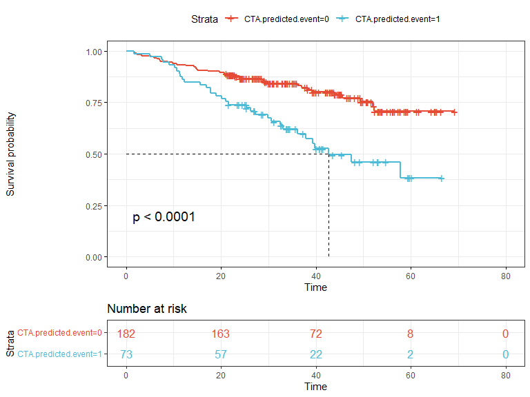

```r
# plot the KM curves for fit0
ggsurvplot(fit0, risk.table = TRUE, risk.table.col = "strata", pval = TRUE,
           surv.median.line = "hv", ggtheme = theme_bw(), palette="npg")
```

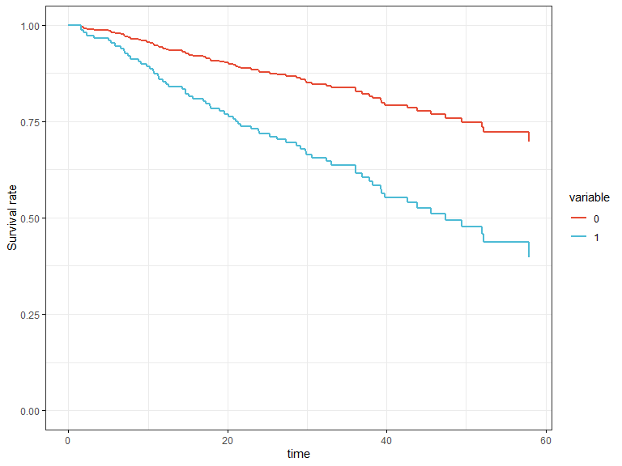

```r
# plot the stratified cox model for fit1 by variable
ggadjustedcurves(fit1, data = myeloma.cta, method = "average", variable = "CTA.predicted.event",
                 ggtheme = theme_bw(), palette="npg")
```

Next, we will create a group prediction for the Run 1 CTA model strata and evaluate these in KM and the Cox model.

```r
### Use Run 1 GO CTA model strata for predicting survival over time ####
cta.model.1.1
```

```
#> $model.3
#>   ATTRIBUTE NODE LEVEL OBS    P   WESS    LOO  WESSL LOOp TYPE    IF THEN
#> 1       V14    1     1 255 .015 14.06% STABLE 14.06% .015  ORD <=0.5    0
#> 2       V15    2     2 211 .001 20.71% STABLE 20.71% .001  ORD <=0.5    0
#>        N1 PERCENT1   IF THEN    N2 PERCENT2
#> 1 160/211   75.83% >0.5    1 18/44  40.91%*
#> 2 146/182  80.22%* >0.5    1 15/29  51.72%*
```

```r
myeloma.cta$group <- with(myeloma.cta, ifelse(
  time != 0,
  ifelse(molecular_group_MMSET <= 0.5,
         ifelse(molecular_group_Proliferation > 0.5, "MMSET=0 & Prolif=1", "MMSET=0 & Prolif=0"),
         "MMSET=1"),
  NA
))

# fit KM to CTA strata
fit2 <- survfit(Surv(time, event) ~group, data = myeloma.cta)

#fit a Cox model to CTA strata
fit3 <- coxph(Surv(time, event) ~group, data = myeloma.cta)
summary(fit3) # this is a parametric cox model fit
```

```
#> Call:
#> coxph(formula = Surv(time, event) ~ group, data = myeloma.cta)
#>
#>   n= 255, number of events= 69
#>    (1 observation deleted due to missingness)
#>
#>                           coef exp(coef) se(coef)     z Pr(>|z|)
#> groupMMSET=0 & Prolif=1 1.1289    3.0921   0.3083 3.662  0.00025 ***
#> groupMMSET=1            0.7962    2.2172   0.2888 2.757  0.00584 **
#> ---
#> Signif. codes:  0 '***' 0.001 '**' 0.01 '*' 0.05 '.' 0.1 ' ' 1
#>
#>                         exp(coef) exp(-coef) lower .95 upper .95
#> groupMMSET=0 & Prolif=1     3.092     0.3234     1.690     5.658
#> groupMMSET=1                2.217     0.4510     1.259     3.905
#>
#> Concordance= 0.608  (se = 0.032 )
#> Likelihood ratio test= 15.15  on 2 df,   p=5e-04
#> Wald test            = 16.27  on 2 df,   p=3e-04
#> Score (logrank) test = 17.68  on 2 df,   p=1e-04
```

```r
AIC(fit3)
```

```
#> [1] 694.6243
```

```r
loglik3 <-logLik(fit3)
loglik3
```

```
#> 'log Lik.' -345.3122 (df=2)
```

```r
cox.zph(fit3)
```

```
#>        chisq df    p
#> group  0.779  2 0.68
#> GLOBAL 0.779  2 0.68
```

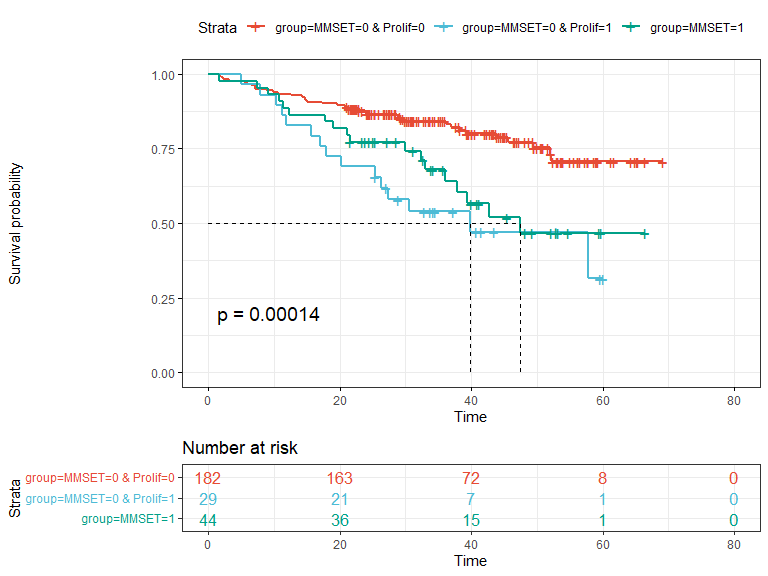

```r
# plot the KM curves for fit2
ggsurvplot(fit2, risk.table = TRUE, risk.table.col = "strata", pval = TRUE,
           surv.median.line = "hv", ggtheme = theme_bw(), palette="npg")
```

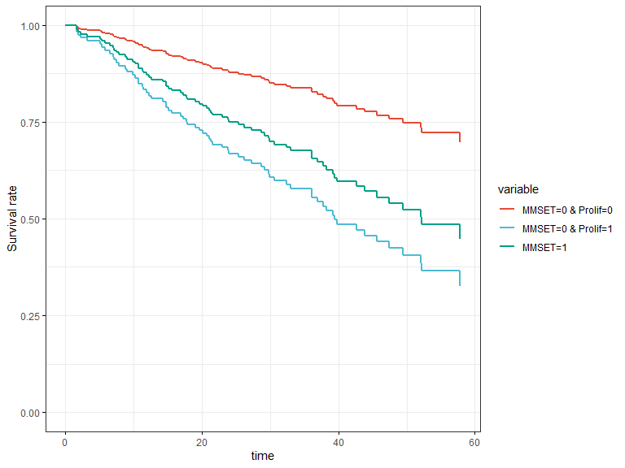

```r
# plot the stratified cox model for fit3 by variable
ggadjustedcurves(fit3, data = myeloma.cta, method = "average", variable = "group",
                 ggtheme = theme_bw(), palette="npg")
```

## Other resources and vignettes for the ODA package

```r
#vignette(package="ODA","Example-1")
#vignette(package="ODA","Example-2")
#vignette(package="ODA","Example-3")
#vignette(package="ODA","Example-4")
```